[interactive chart not shown]

# Decision Tree Classifier (Hotel Cancelation Rate)

#### **Instructor:** [Vijay Gurbani (Chief Data Scientist at Vail Systems, Inc)](https://youtu.be/8oDjrAknr4o?t=11)

#### **Project Summary**

- Cleaned the 'hotel_bookings.csv' dataset, adjusting columns, handling null values, and removing unnecessary columns.
- Analyzed booking cancellation rates, customer types, and car parking space requirements.
- Identified the top countries of origin for both city and resort hotels.
- Split the data into training and testing sets, and constructed a classification model to predict booking cancellations.

#### **About the Dataset**

This dataset contains 119,390 records and 32 features, representing hotel bookings from City and Resort Hotels between July 1, 2015, and August 31, 2017. It includes details such as stay duration, room type, number of guests, meal preferences, and booking cancellations. Sensitive information, like customer identification, has been removed, while artificial fields for names, emails, phone numbers, and credit cards were added. The dataset is ideal for analyzing booking patterns and predicting cancellations.

#### **Libraries Used:** xgboost, rpart, rpart.plot

#### **Key Findings**

Significant insights were gained about booking behaviors, including the high cancellation rate and predominant customer types. The classification model achieved an accuracy of 76.31%, with sensitivity and specificity rates highlighting its predictive strength in identifying cancellations.

#### **Data Visualizations**

Utilized bar plots to represent the distribution of guests from different countries in city and resort hotels. A decision tree visualization provided a clear understanding of the factors influencing booking cancellations.

#### **Conclusions**

The project demonstrated comprehensive data cleaning, exploratory analysis, and predictive modeling skills. It highlighted the importance of data preprocessing in achieving meaningful insights and the efficacy of decision trees in classification tasks.

Decision Tree Classifier

- Return to projects

Sections

- Exploratory Data Analysis
- Plots Showcasing Top 10 Countries for Resort/City Hotels
- Data Cleaning
- Model Selection
- Conclusions

### Exploratory Data Analysis: Hotel Bookings Dataset

I am conducting an Exploratory Data Analysis (EDA) on the 'Hotel Bookings' dataset to uncover trends and patterns, particularly focusing on cancellation rates. The dataset, stored in "hotel_bookings.csv", includes a rich collection of booking records from 'City Hotel' and 'Resort Hotel'. This EDA aims to explore the data through summary statistics and visualizations, seeking insights into the factors influencing cancellation rates. EDA is particularly valuable for gaining insights into a dataset before making any assumptions or building predictive models.

```r
setwd("C:/Users/DirectoryRemoved;)
hotel_bookings <- read.csv("hotel_bookings.csv")

table(hotel_bookings$hotel)
```

```
##
##   City Hotel Resort Hotel
##        79330        40060
```

#### Room Reservation vs Actual Room Assigned

Does the Comparison Between Reserved and Assigned Room Types Impact Cancellation Rates?

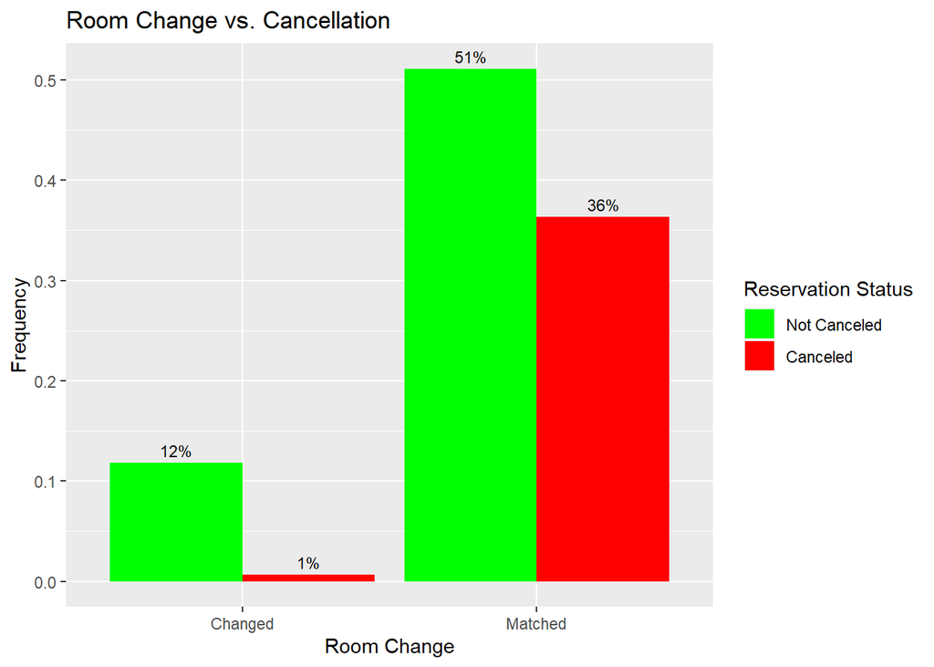

```r
# Analyzing the relationship between room changes and cancellations without modifying the original dataframe
room_change_cancellation_analysis <- hotel_bookings %>%
  mutate(room_match = ifelse(assigned_room_type == reserved_room_type, "Matched", "Changed")) %>%
  group_by(room_match, is_canceled) %>%
  count() %>%
  ungroup() %>%
  mutate(freq = n / sum(n))

# Plot with percentage annotations
ggplot(room_change_cancellation_analysis, aes(x = room_match, y = freq, fill = factor(is_canceled))) +
  geom_bar(stat = "identity", position = position_dodge()) +
  scale_fill_manual(values = c("green", "red"), labels = c("Not Canceled", "Canceled")) +
  labs(title = "Room Change vs. Cancellation", x = "Room Change", y = "Frequency", fill = "Reservation Status") +
  geom_text(aes(label = scales::percent(freq, accuracy = 1)),
            position = position_dodge(width = 0.9),
            vjust = -0.5, size = 3)
```

Contrary to initial expectations, I uncovered a counterintuitive trend: a majority of reservations with matched room types (i.e., the room reserved and the actual room provided) indicated that customers who received the room they requested were more likely to cancel. This is surprising, as one would expect cancellations to be more common among customers who did not get their desired room. This finding prompts a further examination of other variables, as it challenges our initial assumptions.